# Final Project - Penguins Analysis

Anna Kocsis

2024-12-16

```r
# Import libraries
library(tidyverse)
library(stats)
library(lmtest)
library(sandwich)
library(car)
```

## Data Reading and Checking

```r
# Read the data
penguins_raw <- read_csv("https://raw.githubusercontent.com/rfordatascience/tidytuesday/refs/heads/main/data/2020/2020-07-28/penguins.csv")

# Check for missing values in each column
colSums(is.na(penguins_raw))
```

```
##           species            island    bill_length_mm     bill_depth_mm
##                 0                 0                 2                 2
## flipper_length_mm       body_mass_g               sex              year
##                 2                 2                11                 0
```

```r
# Check for unique value count in each column
penguins_raw %>% summarise(across(everything(), n_distinct))
```

```
## # A tibble: 1 × 8
##   species island bill_length_mm bill_depth_mm flipper_length_mm body_mass_g
##     <int>  <int>          <int>         <int>             <int>       <int>
## 1       3      3            165            81                56          95
## # ℹ 2 more variables: sex <int>, year <int>
```

## Data Cleaning

```r
# Clean the data from rows with missing values
penguins_clean <- penguins_raw %>%
  na.omit()

# Check if any missing value remains
colSums(is.na(penguins_clean))
```

```
##           species            island    bill_length_mm     bill_depth_mm
##                 0                 0                 0                 0
## flipper_length_mm       body_mass_g               sex              year
##                 0                 0                 0                 0
```

```r
# Check for unique value count in each column in the clean data
penguins_clean %>% summarise(across(everything(), n_distinct))
```

```
## # A tibble: 1 × 8
##   species island bill_length_mm bill_depth_mm flipper_length_mm body_mass_g
##     <int>  <int>          <int>         <int>             <int>       <int>
## 1       3      3            163            79                54          93
## # ℹ 2 more variables: sex <int>, year <int>
```

## Exploratory Data Analysis

```r
# Head and tail of the cleaned data
head(penguins_clean)
```

```
## # A tibble: 6 × 8
##   species island    bill_length_mm bill_depth_mm flipper_length_mm body_mass_g
##   <chr>   <chr>              <dbl>         <dbl>             <dbl>       <dbl>
## 1 Adelie  Torgersen           39.1          18.7               181        3750
## 2 Adelie  Torgersen           39.5          17.4               186        3800
## 3 Adelie  Torgersen           40.3          18                 195        3250
## 4 Adelie  Torgersen           36.7          19.3               193        3450
## 5 Adelie  Torgersen           39.3          20.6               190        3650
## 6 Adelie  Torgersen           38.9          17.8               181        3625
## # ℹ 2 more variables: sex <chr>, year <dbl>
```

```r
tail(penguins_clean)
```

```
## # A tibble: 6 × 8
##   species   island bill_length_mm bill_depth_mm flipper_length_mm body_mass_g
##   <chr>     <chr>           <dbl>         <dbl>             <dbl>       <dbl>
## 1 Chinstrap Dream            45.7          17                 195        3650
## 2 Chinstrap Dream            55.8          19.8               207        4000
## 3 Chinstrap Dream            43.5          18.1               202        3400
## 4 Chinstrap Dream            49.6          18.2               193        3775
## 5 Chinstrap Dream            50.8          19                 210        4100
## 6 Chinstrap Dream            50.2          18.7               198        3775
## # ℹ 2 more variables: sex <chr>, year <dbl>
```

```r
# Summary of the cleaned data
summary(penguins_clean)
```

```
##    species             island          bill_length_mm  bill_depth_mm
##  Length:333         Length:333         Min.   :32.10   Min.   :13.10
##  Class :character   Class :character   1st Qu.:39.50   1st Qu.:15.60
##  Mode  :character   Mode  :character   Median :44.50   Median :17.30
##                                        Mean   :43.99   Mean   :17.16
##                                        3rd Qu.:48.60   3rd Qu.:18.70
##                                        Max.   :59.60   Max.   :21.50
##  flipper_length_mm  body_mass_g       sex                 year
##  Min.   :172       Min.   :2700   Length:333         Min.   :2007
##  1st Qu.:190       1st Qu.:3550   Class :character   1st Qu.:2007
##  Median :197       Median :4050   Mode  :character   Median :2008
##  Mean   :201       Mean   :4207                      Mean   :2008
##  3rd Qu.:213       3rd Qu.:4775                      3rd Qu.:2009
##  Max.   :231       Max.   :6300                      Max.   :2009
```

### Histograms

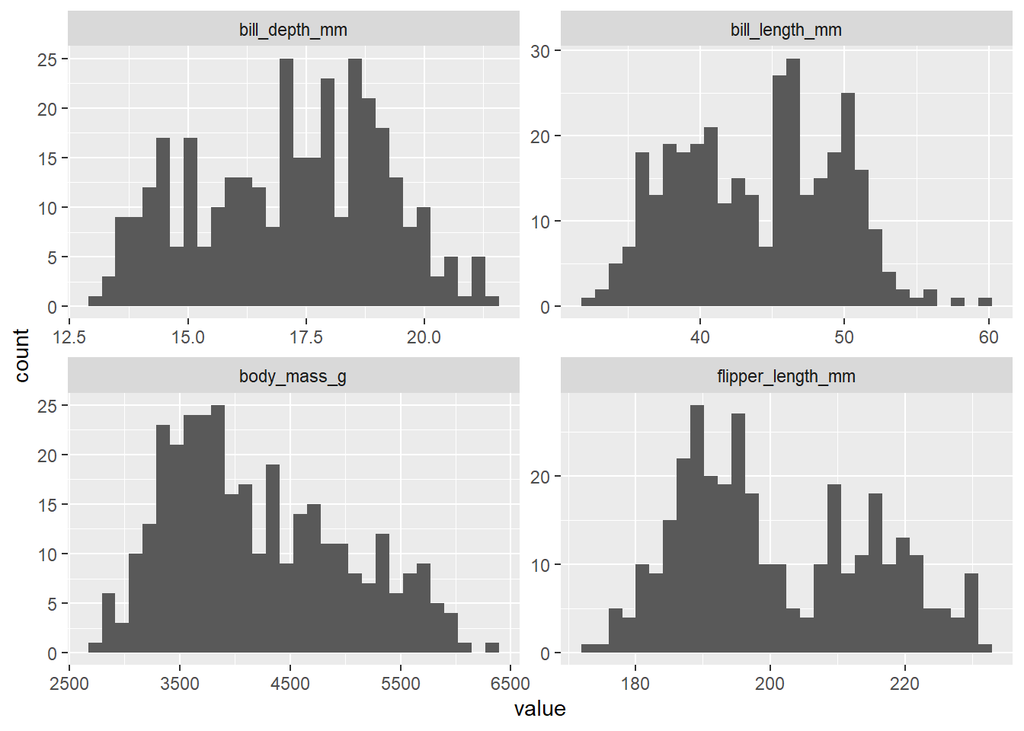

```r
# Histograms for the bill_depth_mm, bill_length_mm, body_mass_g, and flipper_length_mm variables
penguins_clean %>%
  select(
    bill_depth_mm,
    bill_length_mm,
    body_mass_g,
    flipper_length_mm
  ) %>%
  gather(key = "variable", value = "value") %>%
  ggplot(aes(x = value)) +
  geom_histogram(bins = 30) +
  facet_wrap(~variable, scales = "free")
```

A wide variety in bill dimensions, flipper length and body mass can be seen on the histograms.

### Plot 1

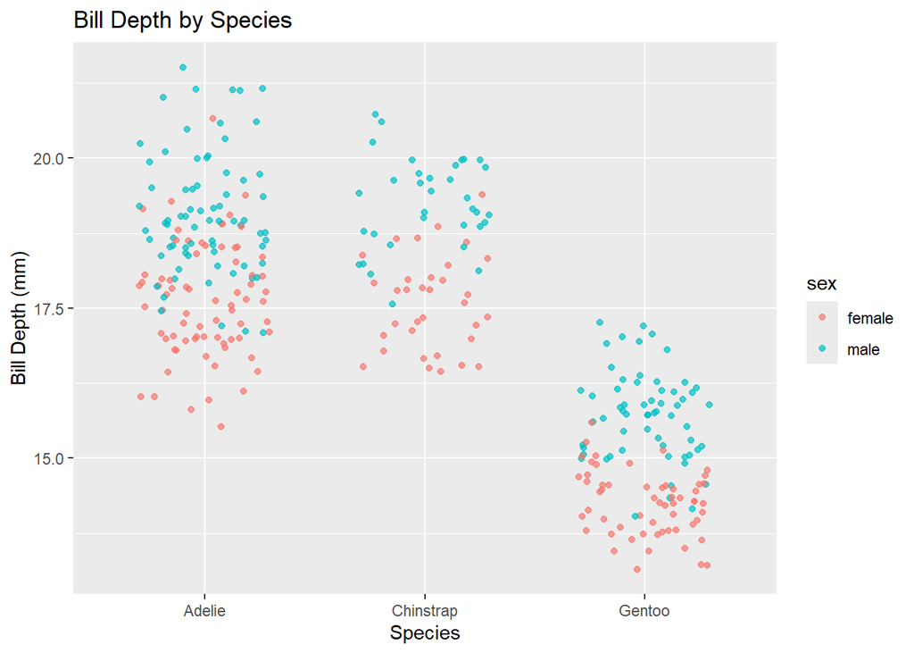

```r
# Plot 1: Flipper length by species
ggplot(penguins_clean, aes(x = species, y = bill_depth_mm, color = sex)) +
  geom_point(position = position_jitter(width = 0.3, height = 0.1), alpha = 0.7) +
  labs(title = "Bill Depth by Species",
       y = "Bill Depth (mm)",
       x = "Species")
```

On Plot 1, we can see that the species of the penguins have some relationship with the bill depth. The Gentoo species tend to have smaller bill depths.

### Plot 2

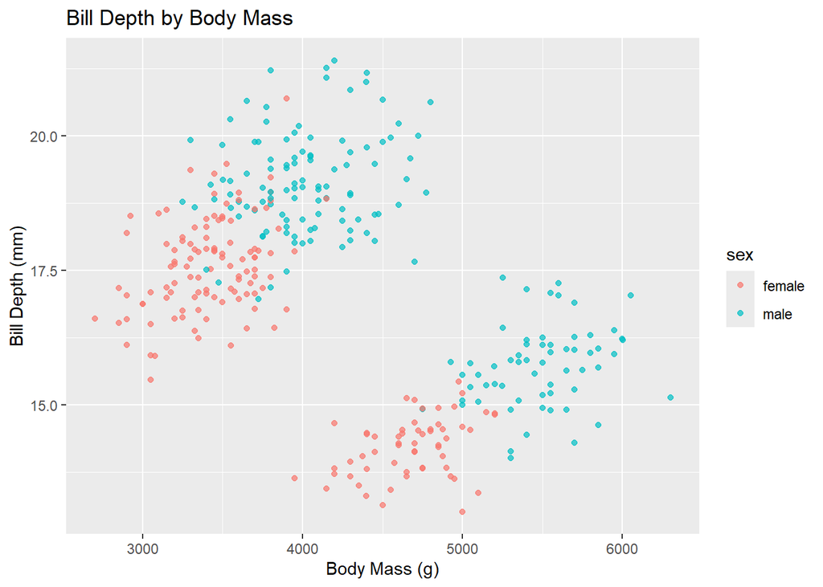

```r
# Plot 2: Flipper length by body mass
ggplot(penguins_clean, aes(x = body_mass_g, y = bill_depth_mm, color = sex)) +
  geom_point(position = position_jitter(width = 0.3, height = 0.1), alpha = 0.7) +
  labs(title = "Bill Depth by Body Mass",
       y = "Bill Depth (mm)",
       x = "Body Mass (g)")
```

On Plot 2, we can see two clusters of observations. This could suggest a more complex relationship between the two variables.

## Hypotheses

**H1:** There is a significant relationship between bill depth (bill_depth_mm) and the predictors species (species) and body mass (body_mass_g) in penguins.

**H2:** Adding sex as an additional predictor improves the model in explaining bill depth (bill_depth_mm), making the model more accurate than the simpler one with species and body mass alone.

## Creating the Models

### Model 1

The first model’s dependent variable is the bill depth and the predictors are species and body mass.

```r
# Model 1: Bill depth as a function of species and body mass
model_1 <- lm(bill_depth_mm ~ species + body_mass_g, data = penguins_clean)
summary(model_1)
```

```
##
## Call:
## lm(formula = bill_depth_mm ~ species + body_mass_g, data = penguins_clean)
##
## Residuals:
##     Min      1Q  Median      3Q     Max
## -2.2635 -0.6090 -0.0039  0.5104  2.7096
##
## Coefficients:
##                    Estimate Std. Error t value Pr(>|t|)
## (Intercept)      12.6931270  0.3954448   32.10   <2e-16 ***
## speciesChinstrap  0.0322529  0.1289282    0.25    0.803
## speciesGentoo    -5.4655224  0.1813741  -30.13   <2e-16 ***
## body_mass_g       0.0015256  0.0001049   14.55   <2e-16 ***
## ---
## Signif. codes:  0 '***' 0.001 '**' 0.01 '*' 0.05 '.' 0.1 ' ' 1
##
## Residual standard error: 0.8779 on 329 degrees of freedom
## Multiple R-squared:  0.803,  Adjusted R-squared:  0.8012
## F-statistic: 447.1 on 3 and 329 DF,  p-value: < 2.2e-16
```

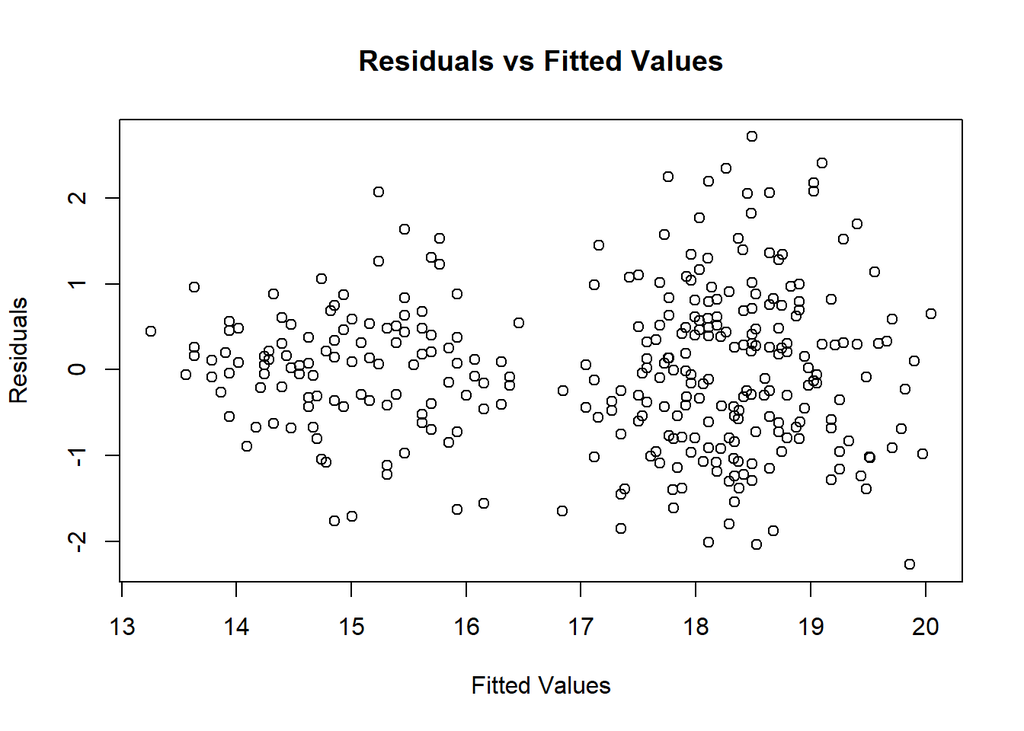

```r
plot(model_1$residuals ~ model_1$fitted.values, main="Residuals vs Fitted Values", xlab="Fitted Values", ylab="Residuals")
```

The results show that body mass has a significant positive effect on bill depth, with a coefficient of b = 0.002 (p < .001). The species variable indicates that Gentoo penguins have a significantly smaller bill depth than Adelie penguins (b = -5.466, p < .001), while Chinstrap penguins do not show a significant difference (b = 0.03, p = 0.803). The model explains 80.3% of the variability in bill depth (R² = 0.803), with a residual standard error of 0.878, and is highly significant (F(3,329) = 447.1, p < .001).

**Regression Equation:** Bill Depth = 12.693 + 0.032 × (Chinstrap) - 5.466 × (Gentoo) + 0.002 × (Body Mass)

### Assumption Checks for Model 1

```r
# Check for normality assumption
shapiro.test(model_1$residuals)
```

```
##
##  Shapiro-Wilk normality test
##
## data:  model_1$residuals
## W = 0.99299, p-value = 0.1217
```

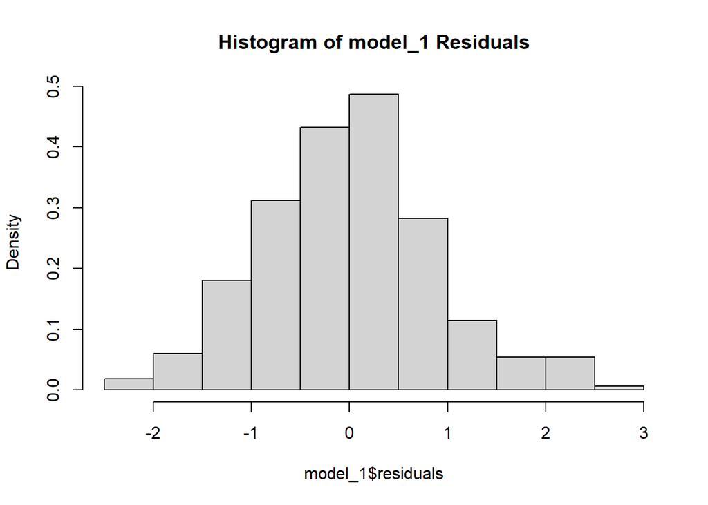

```r
hist(model_1$residuals, probability = TRUE, main = "Histogram of model_1 Residuals")
```

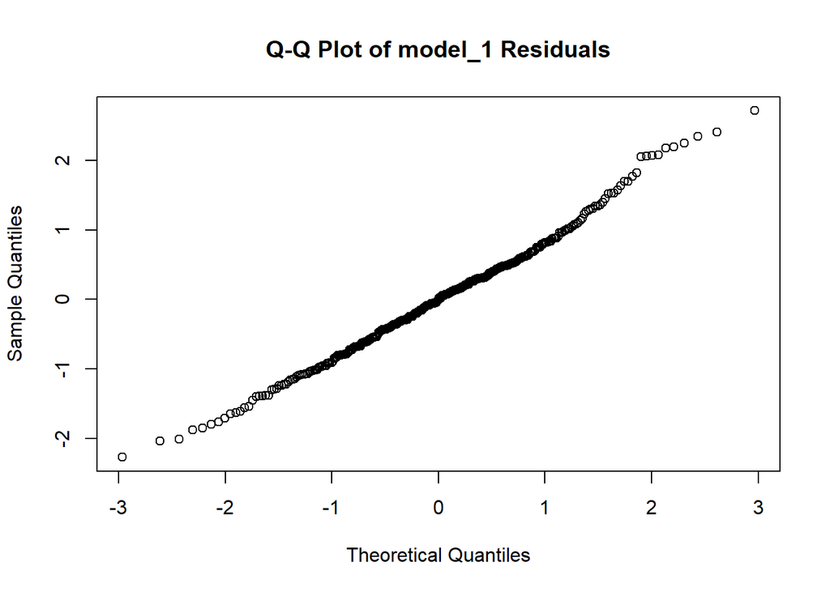

```r
qqnorm(model_1$residuals, main = "Q-Q Plot of model_1 Residuals")
```

```r
# Check for linearity assumption
resettest(model_1, power = 2:3)
```

```
##
##  RESET test
##
## data:  model_1
## RESET = 0.96046, df1 = 2, df2 = 327, p-value = 0.3838
```

```r
# Check for homoscedasticity assumption
bptest(model_1)
```

```
##
##  studentized Breusch-Pagan test
##
## data:  model_1
## BP = 18.3, df = 3, p-value = 0.0003815
```

```r
# Check for multicollinearity
vif(model_1)
```

```
##                GVIF Df GVIF^(1/(2*Df))
## species     3.07209  2        1.323910
## body_mass_g 3.07209  1        1.752738
```

According to the Shapiro-Wilk test, the normality assumption is not violated (p = 0.122). The RESET test shows that the linearity assumption is not violated (p = 0.384). The Breusch-Pagan test shows that the homoscedasticity assumption is violated (p < .001). The Variance Inflation Factor values show that there is no significant multicollinearity in the model (all VIFs < 10).

### Model 2

In Model 2, the predictors remain the same as in Model 1, but since in Model 1 the homoscedasticity assumption is violated, the dependent variable (bill depth) is log-transformed to account for this.

```r
# Model 2: Log-transformed bill depth as a function of species and body mass
model_2 <- lm(log(bill_depth_mm) ~ species + body_mass_g, data = penguins_clean)
summary(model_2)
```

```
##
## Call:
## lm(formula = log(bill_depth_mm) ~ species + body_mass_g, data = penguins_clean)
##
## Residuals:
##       Min        1Q    Median        3Q       Max
## -0.129268 -0.033439 -0.000328  0.032505  0.138213
##
## Coefficients:
##                    Estimate Std. Error t value Pr(>|t|)
## (Intercept)       2.572e+00  2.250e-02 114.304   <2e-16 ***
## speciesChinstrap  1.853e-03  7.337e-03   0.252    0.801
## speciesGentoo    -3.270e-01  1.032e-02 -31.678   <2e-16 ***
## body_mass_g       9.042e-05  5.968e-06  15.150   <2e-16 ***
## ---
## Signif. codes:  0 '***' 0.001 '**' 0.01 '*' 0.05 '.' 0.1 ' ' 1
##
## Residual standard error: 0.04996 on 329 degrees of freedom
## Multiple R-squared:  0.8193, Adjusted R-squared:  0.8177
## F-statistic: 497.3 on 3 and 329 DF,  p-value: < 2.2e-16
```

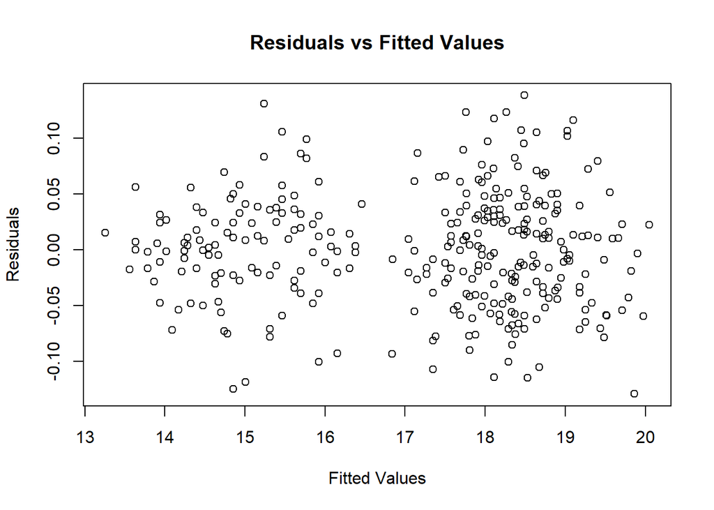

```r
plot(model_2$residuals ~ model_1$fitted.values, main="Residuals vs Fitted Values", xlab="Fitted Values", ylab="Residuals")
```

The results show that body mass has a significant positive effect on log-transformed bill depth, with a coefficient of b = 0.00009 (p < .001). The species variable indicates that Gentoo penguins have a significantly smaller log-transformed bill depth than Adelie penguins (b = -0.327, p < .001), while Chinstrap penguins do not show a significant difference (b = 0.002, p = 0.801). The model explains 81.93% of the variability in log-transformed bill depth (R² = 0.819), with a residual standard error of 0.050, and is highly significant (F(3, 329) = 497.3, p < .001).

**Regression Equation:** Log(Bill Depth) = 2.572 + 0.002 × (Chinstrap) - 0.327 × (Gentoo) + 0.00009 × (Body Mass)

### Assumption Checks for Model 2

```r
# Check for normality assumption
shapiro.test(model_2$residuals)
```

```
##
##  Shapiro-Wilk normality test
##
## data:  model_2$residuals
## W = 0.9964, p-value = 0.6584
```

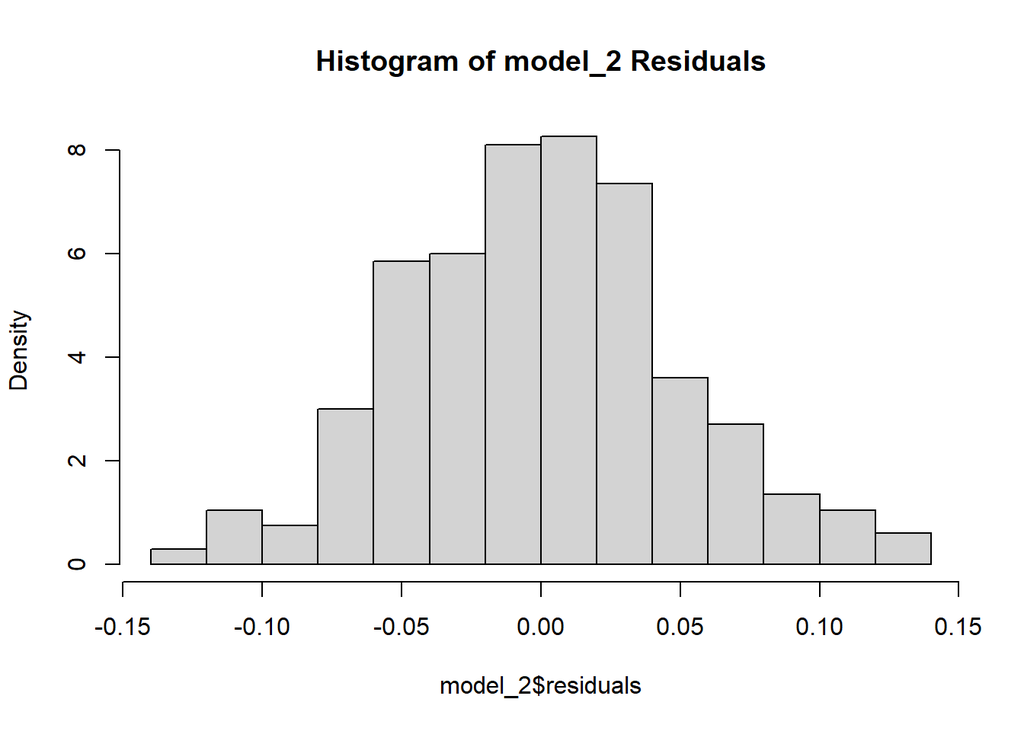

```r
hist(model_2$residuals, probability = TRUE, main = "Histogram of model_2 Residuals")
```

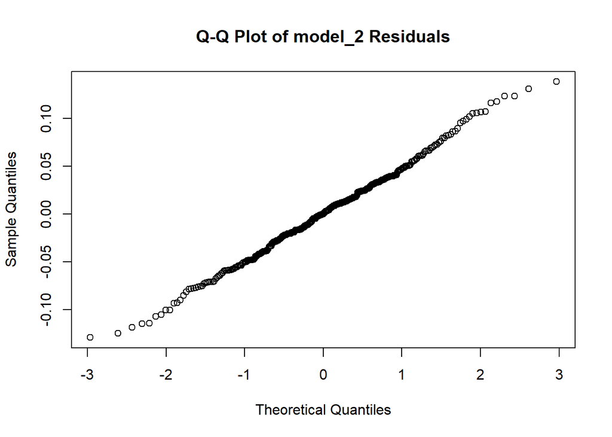

```r
qqnorm(model_2$residuals, main = "Q-Q Plot of model_2 Residuals")
```

```r
# Check for linearity assumption
resettest(model_2, power = 2:3)
```

```
##
##  RESET test
##
## data:  model_2
## RESET = 1.3198, df1 = 2, df2 = 327, p-value = 0.2686
```

```r
# Check for homoscedasticity assumption
bptest(model_2)
```

```
##
##  studentized Breusch-Pagan test
##
## data:  model_2
## BP = 7.0139, df = 3, p-value = 0.07146
```

```r
# Check for multicollinearity
vif(model_2)
```

```
##                GVIF Df GVIF^(1/(2*Df))
## species     3.07209  2        1.323910
## body_mass_g 3.07209  1        1.752738
```

According to the Shapiro-Wilk test, the normality assumption is not violated (p = 0.658). The RESET test shows that the linearity assumption is not violated (p = 0.269). The Breusch-Pagan test indicates that the homoscedasticity assumption is not violated (p = 0.072). The Variance Inflation Factor values show that there is no significant multicollinearity in the model (all VIFs < 10).

### Model 3

Model 3 is a hierarchically more complex model than Model 2, with the variable sex as a new predictor.

```r
# Model 3: Logarithmically transformed bill depth as a function of species, body mass, and sex
model_3 <- lm(log(bill_depth_mm) ~ species + body_mass_g + sex, data = penguins_clean)
summary(model_3)
```

```
##
## Call:
## lm(formula = log(bill_depth_mm) ~ species + body_mass_g + sex,
##     data = penguins_clean)
##
## Residuals:
##       Min        1Q    Median        3Q       Max
## -0.112108 -0.031162 -0.000089  0.025558  0.144244
##
## Coefficients:
##                    Estimate Std. Error t value Pr(>|t|)
## (Intercept)       2.717e+00  2.716e-02 100.050  < 2e-16 ***
## speciesChinstrap  3.124e-03  6.699e-03   0.466    0.641
## speciesGentoo    -2.622e-01  1.231e-02 -21.307  < 2e-16 ***
## body_mass_g       4.319e-05  7.941e-06   5.438 1.05e-07 ***
## sexmale           5.957e-02  7.286e-03   8.175 6.52e-15 ***
## ---
## Signif. codes:  0 '***' 0.001 '**' 0.01 '*' 0.05 '.' 0.1 ' ' 1
##
## Residual standard error: 0.04561 on 328 degrees of freedom
## Multiple R-squared:  0.8499, Adjusted R-squared:  0.8481
## F-statistic: 464.4 on 4 and 328 DF,  p-value: < 2.2e-16
```

The results show that body mass has a significant positive effect on log-transformed bill depth, with a coefficient of 4.32 × 10⁻⁵ (p < .001). The species variable indicates that Gentoo penguins have a significantly smaller log-transformed bill depth than Adelie penguins (coefficient = -0.2622, p < .001), while Chinstrap penguins do not show a significant difference (coefficient = 0.003, p = 0.641). The sex variable indicates that male penguins have a significantly larger log-transformed bill depth than females (coefficient = 0.060, p < .001). The model explains 84.99% of the variability in log-transformed bill depth (R² = 0.85), with a residual standard error of 0.046, and is highly significant (F(4, 328) = 464.4, p < .001).

**Regression Equation:** Log(Bill Depth) = 2.717 + 0.0031 × (Chinstrap) - 0.2622 × (Gentoo) + 0.00004319 × (Body Mass) + 0.0596 × (Sex[Male])

### Assumption Checks for Model 3

```r
# Check for normality assumption
shapiro.test(model_3$residuals)
```

```
##
##  Shapiro-Wilk normality test
##
## data:  model_3$residuals
## W = 0.99582, p-value = 0.521
```

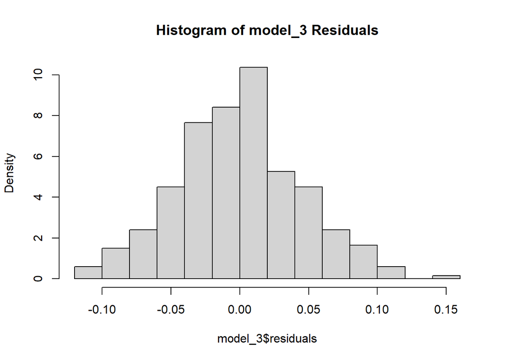

```r
hist(model_3$residuals, probability = TRUE, main = "Histogram of model_3 Residuals")
```

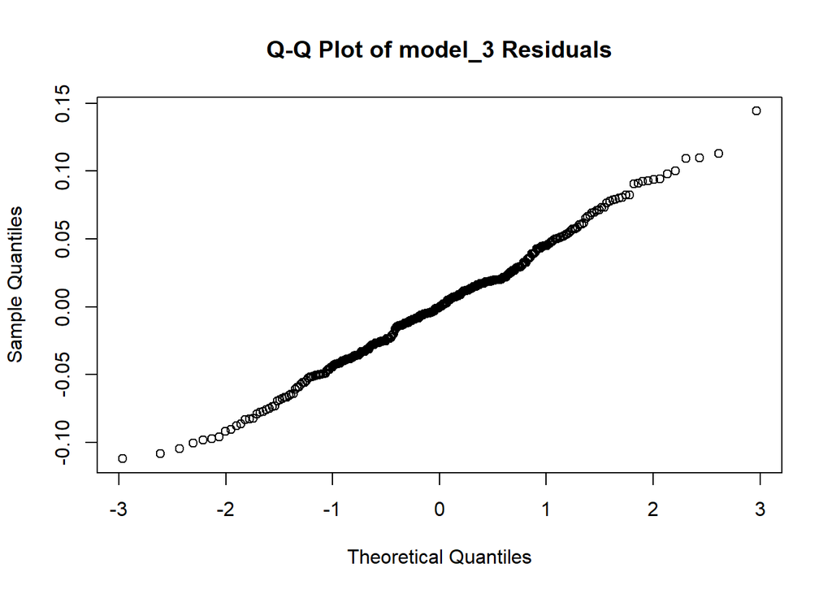

```r
qqnorm(model_3$residuals, main = "Q-Q Plot of model_3 Residuals")
```

```r
# Check for linearity assumption
resettest(model_3, power = 2:3)
```

```
##
##  RESET test
##
## data:  model_3
## RESET = 0.808, df1 = 2, df2 = 326, p-value = 0.4466
```

```r
# Check for homoscedasticity assumption
bptest(model_3)
```

```
##
##  studentized Breusch-Pagan test
##
## data:  model_3
## BP = 14.084, df = 4, p-value = 0.007033
```

```r
# Check for multicollinearity
vif(model_3)
```

```
##                 GVIF Df GVIF^(1/(2*Df))
## species     5.349026  2        1.520788
## body_mass_g 6.527137  1        2.554826
## sex         2.124967  1        1.457727
```

According to the Shapiro-Wilk normality test, the normality assumption is not violated (p = 0.521). The RESET test shows that the linearity assumption is not violated (p = 0.447). The Breusch-Pagan test indicates that the homoscedasticity assumption is violated (p = 0.007). The Variance Inflation Factor values show that there is no significant multicollinearity in the model.

### Heteroscedasticity-Consistent Covariance Matrix Estimation for Model 3

Even though in Model 3 I used the log-transformed dependent variable for bill depth, the homoscedasticity assumption is still violated, therefore we need a Heteroscedasticity-Consistent Covariance Matrix Estimation for interpreting the results.

```r
# Heteroscedasticity-Consistent Covariance Matrix Estimation
coeftest(model_3, vcov = vcovHC(model_3, type = "HC3"))
```

```
##
## t test of coefficients:
##
##                     Estimate  Std. Error  t value  Pr(>|t|)
## (Intercept)       2.7175e+00  2.7491e-02  98.8493 < 2.2e-16 ***
## speciesChinstrap  3.1243e-03  6.4883e-03   0.4815    0.6305
## speciesGentoo    -2.6222e-01  1.2450e-02 -21.0613 < 2.2e-16 ***
## body_mass_g       4.3186e-05  8.1462e-06   5.3013 2.116e-07 ***
## sexmale           5.9569e-02  7.5294e-03   7.9115 3.938e-14 ***
## ---
## Signif. codes:  0 '***' 0.001 '**' 0.01 '*' 0.05 '.' 0.1 ' ' 1
```

The results show that body mass has a significant positive effect on log-transformed bill depth (b = 0.00004, p < .001), and male penguins have a significantly larger log-transformed bill depth than females (b = 0.060, p < .001). Gentoo penguins have a significantly smaller log-transformed bill depth than Adelie penguins (b = -0.262, p < .001), while Chinstrap penguins do not show a significant difference (b = 0.003, p = 0.631)

## Model Comparison

```r
# Comparing model_2 and model_3
anova(model_2, model_3)
```

```
## Analysis of Variance Table
##
## Model 1: log(bill_depth_mm) ~ species + body_mass_g
## Model 2: log(bill_depth_mm) ~ species + body_mass_g + sex
##   Res.Df     RSS Df Sum of Sq      F    Pr(>F)
## 1    329 0.82119
## 2    328 0.68218  1   0.13901 66.836 6.519e-15 ***
## ---
## Signif. codes:  0 '***' 0.001 '**' 0.01 '*' 0.05 '.' 0.1 ' ' 1
```

```r
AIC(model_2)
```

```
## [1] -1044.7
```

```r
AIC(model_3)
```

```
## [1] -1104.457
```

Additionally, the Akaike Information Criterion (AIC) supports the improved fit of Model 3, with a lower AIC value of -1104.46 compared to -1044.7 for Model 2. A lower AIC suggests that Model 3 is a better model, as it balances goodness of fit with model complexity.

## Discussion

In this analysis, I tested two hypotheses: (H1) that species and body mass influence bill depth, and (H2) that adding sex as a predictor would improve the model. Model 1 confirmed the first hypothesis (H1), showing significant effects of body mass and species on bill depth. In Model 2, which log-transformed the dependent variable, I found similar results with a slightly better fit. Model 3, which included sex as an additional predictor, supported the second hypothesis (H2), revealing that male penguins have larger bill depths than females. The addition of sex improved the model’s explanatory power, as evidenced by a lower AIC and higher R-squared. These findings highlight the important role of species, body mass, and sex in explaining penguin bill depth, a trait that plays a key role in feeding and survival.